# Analysis

19 marzo, 2020

# 1 Análisis PPM-S

# 2 Wave 01

```r
library(sjPlot)
library(dplyr)
library(lavaan)
library(stargazer)
library(corrplot)
library(psych)
library(knitr)
library(kableExtra)
```

```r
data01 <- sjlabelled::read_spss(path = "input/data/original/Estudio_3_ola1.sav",verbose = FALSE)

dat01 <- data01 %>% filter(Intro==1,Finished==1) %>% select(starts_with("meritv01")) %>% na.omit()
dat02 <- data01 %>% filter(Intro==1,Finished==1) %>% select(starts_with("meritv02")) %>% na.omit()
dat03 <- data01 %>% filter(Intro==1,Finished==1) %>% select(starts_with("meritv03_p")) %>% na.omit()

# - Nos quedamos solamente con los casos que ACEPTARON participar y terminaron el cuestionario.
# - Para dejar una base que contenga solamente los casos que tienen información completa en los ítems usamos na.omit()

dat04 <- data01 %>% filter(Intro==1) %>%
  select(starts_with("meritv01"),
         starts_with("meritv02"),
         starts_with("meritv03_p"),
         starts_with("FL_21_DO"))
dat04$grupo <- NA
dat04$grupo[dat04$FL_21_DO_merit_perc_pref_julio19v01==1] <- 1
dat04$grupo[dat04$FL_21_DO_merit_perc_pref_julio19v02==1] <- 2
dat04$grupo[dat04$FL_21_DO_merit_perc_pref_julio19v03==1] <- 3
dat04$perc_effort <- rowSums(dat04[,c(matches(match = "perc_effort",vars = names(dat04)))],na.rm = TRUE)
dat04$perc_talent <- rowSums(dat04[,c(matches(match = "perc_talent",vars = names(dat04)))],na.rm = TRUE)
dat04$perc_wpart  <- rowSums(dat04[,c(matches(match = "perc_wpart" ,vars = names(dat04)))],na.rm = TRUE)
dat04$perc_netw   <- rowSums(dat04[,c(matches(match = "perc_netw"  ,vars = names(dat04)))],na.rm = TRUE)

dat04$pref_effort <- rowSums(dat04[,c(matches(match = "pref_effort",vars = names(dat04)))],na.rm = TRUE)
dat04$pref_talent <- rowSums(dat04[,c(matches(match = "pref_talent",vars = names(dat04)))],na.rm = TRUE)
dat04$pref_wpart  <- rowSums(dat04[,c(matches(match = "pref_wpart" ,vars = names(dat04)))],na.rm = TRUE)
dat04$pref_netw   <- rowSums(dat04[,c(matches(match = "pref_netw"  ,vars = names(dat04)))],na.rm = TRUE)
dat04[dat04==0] <- NA
```

## 2.1 Version 01: Fixed order by perception / preferences (N=697)

1. Percepcion esfuerzo
2. Percepcion talento
3. Percepcion familia rica
4. Percepcion redes
5. Preferencia esfuerzo
6. Preferencia talento
7. Preferencia familia rica
8. Preferencia redes

| Statistic | N | Mean | St. Dev. | Min | Pctl(25) | Pctl(75) | Max |
| --- | --- | --- | --- | --- | --- | --- | --- |
| meritv01_perc_effort | 697 | 3.164 | 1.360 | 1 | 2 | 4 | 5 |
| meritv01_perc_talent | 697 | 2.981 | 1.122 | 1 | 2 | 4 | 5 |
| meritv01_perc_wpart | 697 | 3.603 | 1.353 | 1 | 3 | 5 | 5 |
| meritv01_perc_netw | 697 | 3.740 | 1.255 | 1 | 3 | 5 | 5 |
| meritv01_pref_effort | 697 | 3.908 | 1.225 | 1 | 3 | 5 | 5 |
| meritv01_pref_talent | 697 | 3.268 | 1.168 | 1 | 3 | 4 | 5 |
| meritv01_pref_wpart | 697 | 2.555 | 1.117 | 1 | 2 | 3 | 5 |
| meritv01_pref_netw | 697 | 2.337 | 1.057 | 1 | 1 | 3 | 5 |

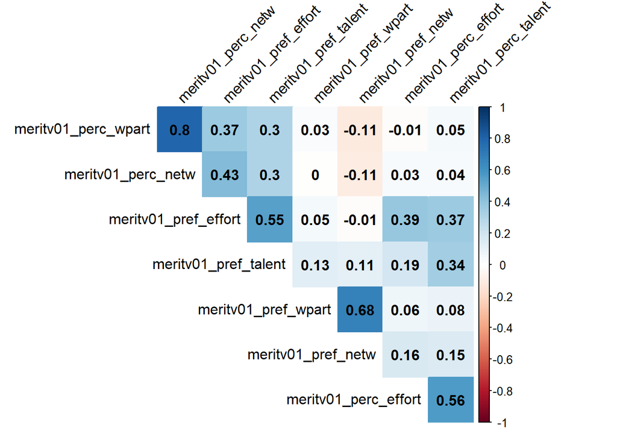

```r
cor01<-polychoric(dat01)
corrplot(cor01$rho,method = "color" ,type = "upper", order = "hclust", tl.col = "black", tl.srt = 45,addCoef.col = "black",diag = FALSE)
```

```r
model01 <- '
perc_merit=~meritv01_perc_effort+meritv01_perc_talent
perc_nmerit=~meritv01_perc_wpart+meritv01_perc_netw
pref_merit=~meritv01_pref_effort+meritv01_pref_talent
pref_nmerit=~meritv01_pref_wpart+meritv01_pref_netw'

fit1_c <- cfa(model = model01,data = dat01,estimator="MLR") # Continuo/ estimador ML Robust

fit1_o <- cfa(model = model01,data = dat01,
            ordered = c("meritv01_perc_effort","meritv01_perc_talent",
                        "meritv01_perc_wpart","meritv01_perc_netw",
                        "meritv01_pref_effort","meritv01_pref_talent",
                        "meritv01_pref_wpart","meritv01_pref_netw"))

#---------------------------------------------------#
# #summary(fit1_c,standardized=TRUE, fit.measures=TRUE)}
fitmeasures(fit1_c)[c("chisq.scaled","df","cfi","cfi.scaled","cfi.robust","rmsea","rmsea.scaled","rmsea.robust")]
```

```
## chisq.scaled           df          cfi   cfi.scaled   cfi.robust
##  42.93480226  14.00000000   0.97948028   0.97736086   0.98021257
##        rmsea rmsea.scaled rmsea.robust
##   0.05812794   0.05445401   0.05695600
```

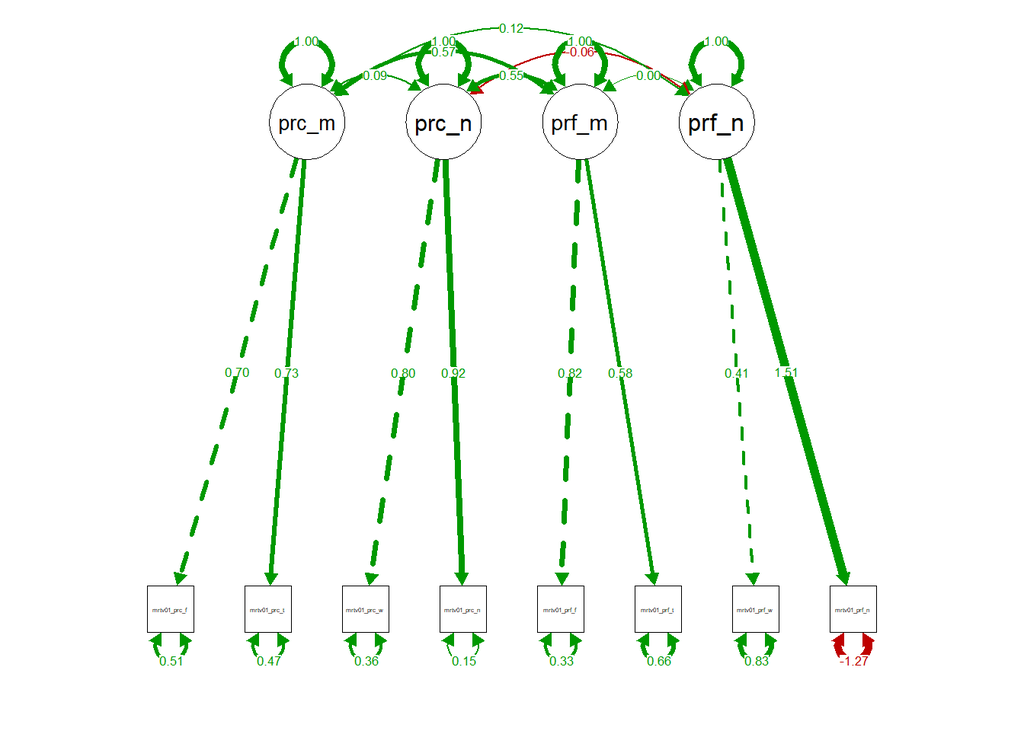

```r
semPlot::semPaths(object = fit1_c,what = "std",thresholds = FALSE, intercepts = FALSE,fade=FALSE, curve = 1.5)
```

```r
# #summary(fit1_o,standardized=TRUE, fit.measures=TRUE)
fitmeasures(fit1_o)[c("chisq.scaled","df","cfi","cfi.scaled","cfi.robust","rmsea","rmsea.scaled","rmsea.robust")]
```

```
## chisq.scaled           df          cfi   cfi.scaled   cfi.robust
##  46.11414265  14.00000000   0.99763575   0.99207488           NA
##        rmsea rmsea.scaled rmsea.robust
##   0.03794574   0.05740894           NA
```

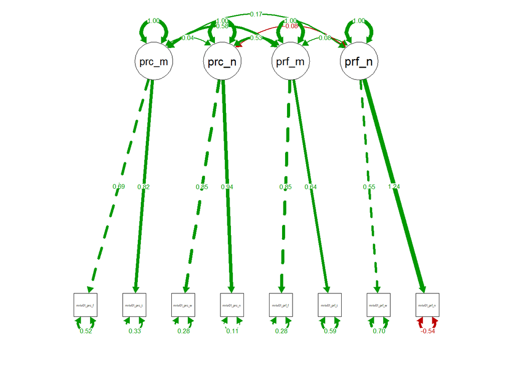

```r
semPlot::semPaths(object = fit1_o,what = "std",thresholds = FALSE, intercepts = FALSE,fade=FALSE, curve = 1.5)
```

> *#summary*: good fit, heywood case item 8.

## 2.2 Version 02: Fixed order, by topic (N=706)

1. Percepcion esfuerzo
2. Preferencia esfuerzo
3. Percepcion talento
4. Preferencia talento
5. Percepcion familia rica
6. Preferencia familia rica
7. Percepcion redes
8. Preferencia redes

| Statistic | N | Mean | St. Dev. | Min | Pctl(25) | Pctl(75) | Max |
| --- | --- | --- | --- | --- | --- | --- | --- |
| meritv02_perc_effort | 706 | 3.105 | 1.399 | 1 | 2 | 4 | 5 |
| meritv02_pref_effort | 706 | 3.741 | 1.339 | 1 | 3 | 5 | 5 |
| meritv02_perc_talent | 706 | 3.035 | 1.111 | 1 | 2 | 4 | 5 |
| meritv02_pref_talent | 706 | 3.146 | 1.149 | 1 | 2 | 4 | 5 |
| meritv02_perc_wpart | 706 | 3.661 | 1.364 | 1 | 3 | 5 | 5 |
| meritv02_pref_wpart | 706 | 2.742 | 1.209 | 1 | 2 | 4 | 5 |
| meritv02_perc_netw | 706 | 3.728 | 1.218 | 1 | 3 | 5 | 5 |
| meritv02_pref_netw | 706 | 2.385 | 1.109 | 1 | 1 | 3 | 5 |

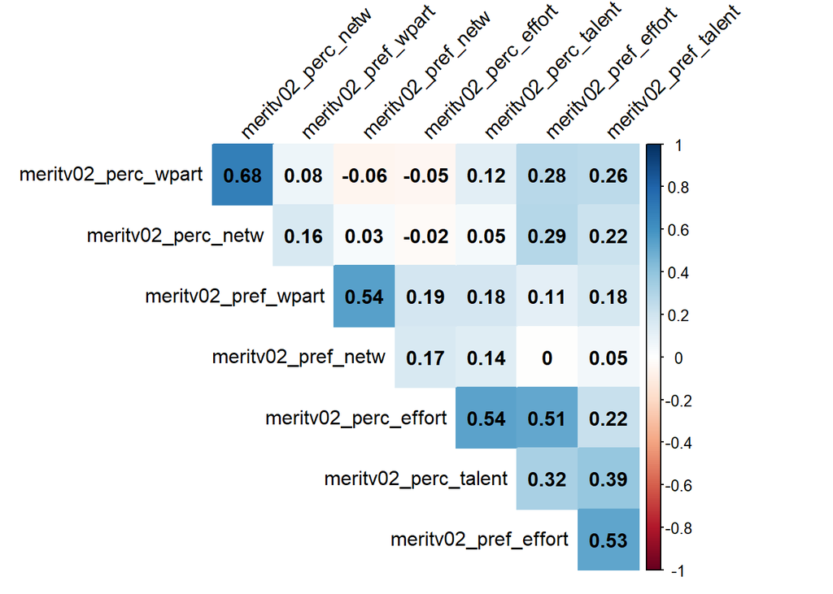

```r
cor02<-polychoric(dat02)
corrplot(cor02$rho,method = "color", type = "upper", order = "hclust", tl.col = "black", tl.srt = 45,addCoef.col = "black",diag = FALSE)
```

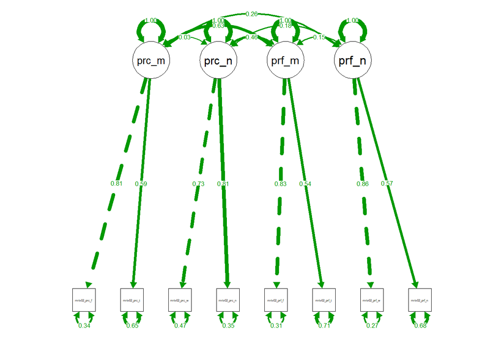

```r
model02 <- '
perc_merit=~meritv02_perc_effort+meritv02_perc_talent
perc_nmerit=~meritv02_perc_wpart+meritv02_perc_netw
pref_merit=~meritv02_pref_effort+meritv02_pref_talent
pref_nmerit=~meritv02_pref_wpart+meritv02_pref_netw'

fit2_c <- cfa(model = model02,data = dat02,estimator="MLR") # Continuo/ estimador ML Robust

fit2_o <- cfa(model = model02,data = dat02,ordered = c("meritv02_perc_effort","meritv02_perc_talent",
                                                     "meritv02_perc_wpart","meritv02_perc_netw",
                                                     "meritv02_pref_effort","meritv02_pref_talent",
                                                     "meritv02_pref_wpart","meritv02_pref_netw"))

#---------------------------------------------------#
#summary(fit2_c,standardized=TRUE, fit.measures=TRUE)
fitmeasures(fit2_c)[c("chisq.scaled","df","cfi","cfi.scaled","cfi.robust","rmsea","rmsea.scaled","rmsea.robust")]
semPlot::semPaths(object = fit2_c,what = "std",thresholds = FALSE, intercepts = FALSE,fade=FALSE, curve = 1.5)
```

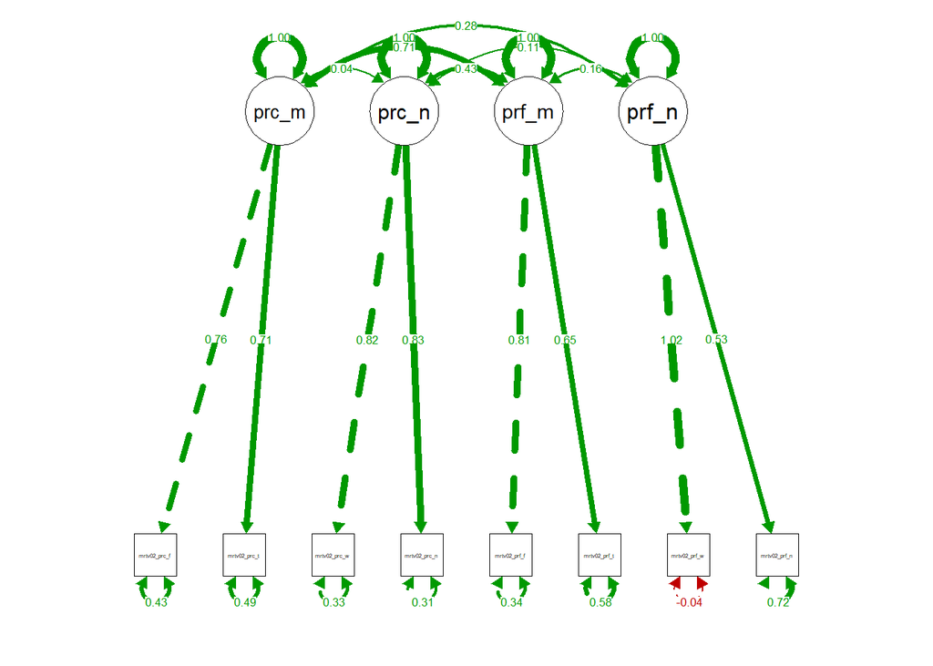

```
## chisq.scaled           df          cfi   cfi.scaled   cfi.robust
## 100.06185323  14.00000000   0.92567916   0.91208862   0.92577394
##        rmsea rmsea.scaled rmsea.robust
##   0.09562704   0.09331232   0.09530656
## chisq.scaled           df          cfi   cfi.scaled   cfi.robust
## 101.48249122  14.00000000   0.98421904   0.96229187           NA
##        rmsea rmsea.scaled rmsea.robust
##   0.07128592   0.09414603           NA
```

```r
#summary(fit2_o,standardized=TRUE, fit.measures=TRUE)
fitmeasures(fit2_o)[c("chisq.scaled","df","cfi","cfi.scaled","cfi.robust","rmsea","rmsea.scaled","rmsea.robust")]
semPlot::semPaths(object = fit2_o,what = "std",thresholds = FALSE, intercepts = FALSE,fade=FALSE, curve = 1.5)
```

> **NOTA**: bad fit, heywood en estimación DWLS

## 2.3 Version 03: Random order (N=697)

| Statistic | N | Mean | St. Dev. | Min | Pctl(25) | Pctl(75) | Max |
| --- | --- | --- | --- | --- | --- | --- | --- |
| meritv03_perc_effort | 697 | 3.329 | 1.370 | 1 | 2 | 5 | 5 |
| meritv03_perc_talent | 697 | 3.072 | 1.245 | 1 | 2 | 4 | 5 |
| meritv03_perc_wpart | 697 | 3.722 | 1.360 | 1 | 3 | 5 | 5 |
| meritv03_perc_netw | 697 | 3.900 | 1.235 | 1 | 3 | 5 | 5 |
| meritv03_pref_effort | 697 | 4.046 | 1.159 | 1 | 4 | 5 | 5 |
| meritv03_pref_talent | 697 | 3.339 | 1.229 | 1 | 2 | 4 | 5 |
| meritv03_pref_wpart | 697 | 2.770 | 1.189 | 1 | 2 | 4 | 5 |
| meritv03_pref_netw | 697 | 2.506 | 1.144 | 1 | 2 | 3 | 5 |

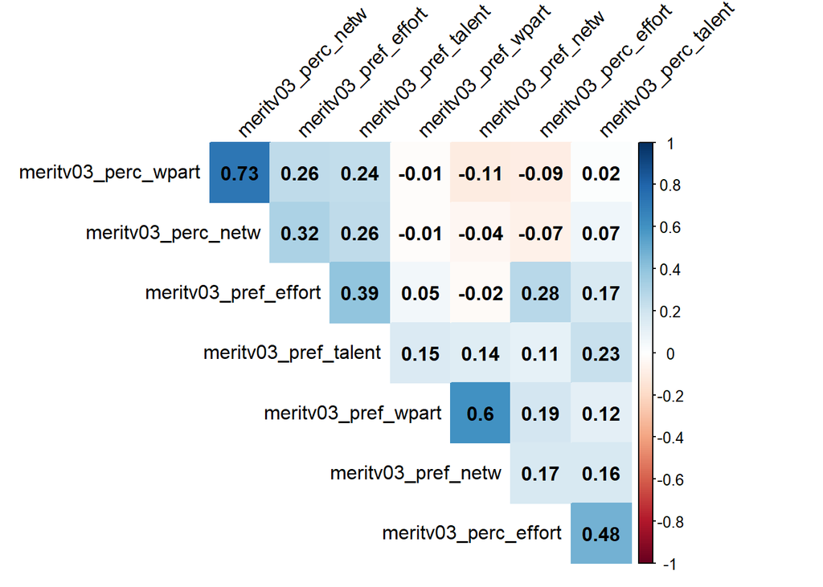

```r
cor03<-polychoric(dat03)
corrplot(cor03$rho,method = "color", type = "upper", order = "hclust", tl.col = "black", tl.srt = 45,addCoef.col = "black",diag = FALSE)
```

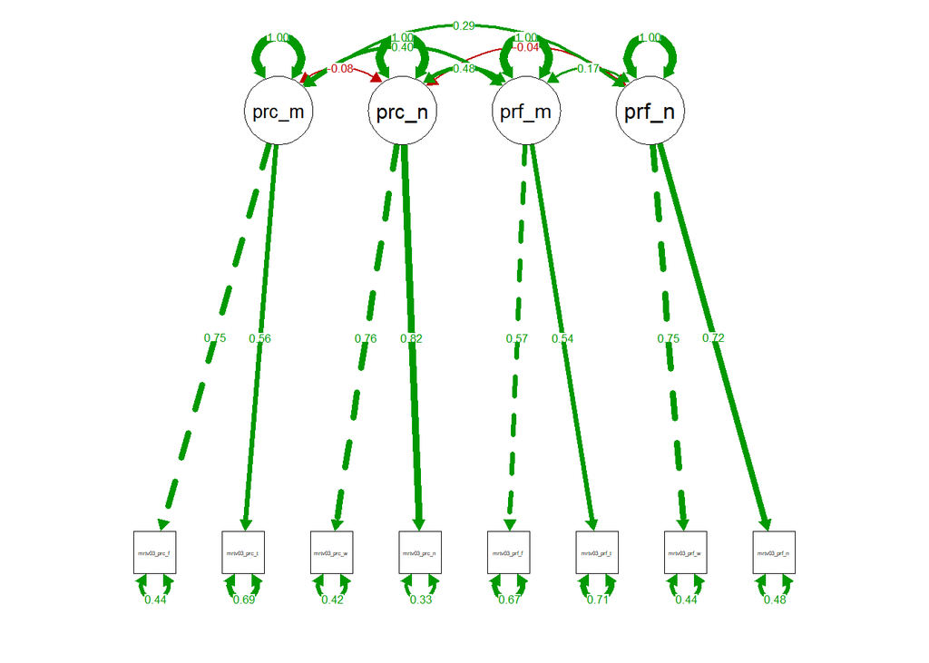

```r
model03 <- '
perc_merit=~meritv03_perc_effort+meritv03_perc_talent
perc_nmerit=~meritv03_perc_wpart+meritv03_perc_netw
pref_merit=~meritv03_pref_effort+meritv03_pref_talent
pref_nmerit=~meritv03_pref_wpart+meritv03_pref_netw'

fit3_c <- cfa(model = model03,data = dat03,estimator="MLR",std.lv=FALSE) # Continuo/ estimador ML Robust

fit3_o <- cfa(model = model03,data = dat03,ordered = c("meritv03_perc_effort","meritv03_perc_talent",
                                                       "meritv03_perc_wpart","meritv03_perc_netw",
                                                       "meritv03_pref_effort","meritv03_pref_talent",
                                                       "meritv03_pref_wpart","meritv03_pref_netw"),std.lv=FALSE)
#---------------------------------------------------#
#summary(fit3_c,standardized=TRUE, fit.measures=TRUE)
fitmeasures(fit3_c)[c("chisq.scaled","df","cfi","cfi.scaled","cfi.robust","rmsea","rmsea.scaled","rmsea.robust")]
semPlot::semPaths(object = fit3_c,what = "std",thresholds = FALSE, intercepts = FALSE,fade=FALSE, curve = 1.5)
```

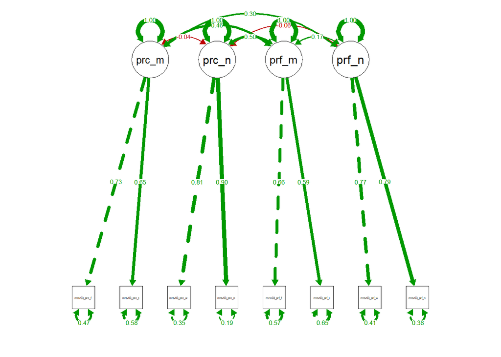

```
## chisq.scaled           df          cfi   cfi.scaled   cfi.robust
##   57.0584003   14.0000000    0.9519967    0.9424676    0.9523832
##        rmsea rmsea.scaled rmsea.robust
##    0.0686923    0.0664276    0.0681436
## chisq.scaled           df          cfi   cfi.scaled   cfi.robust
##  60.02456981  14.00000000   0.99183602   0.98040527           NA
##        rmsea rmsea.scaled rmsea.robust
##   0.05074320   0.06872682           NA
```

```r
#summary(fit3_o,standardized=TRUE, fit.measures=TRUE)
fitmeasures(fit3_o)[c("chisq.scaled","df","cfi","cfi.scaled","cfi.robust","rmsea","rmsea.scaled","rmsea.robust")]
semPlot::semPaths(object = fit3_o,what = "std",thresholds = FALSE, intercepts = FALSE,fade=FALSE, curve = 1.5)
```

> **NOTA**: fit not very goood (RMSEA .7), no heywood. Try tau-equivalence

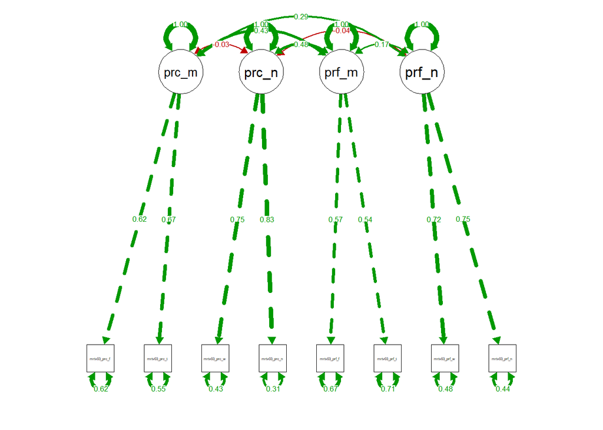

```r
model03.tau <- '
perc_merit=~ r1*meritv03_perc_effort+r1*meritv03_perc_talent
perc_nmerit=~r2*meritv03_perc_wpart+ r2*meritv03_perc_netw
pref_merit=~ r3*meritv03_pref_effort+r3*meritv03_pref_talent
pref_nmerit=~r4*meritv03_pref_wpart+ r4*meritv03_pref_netw'

fit3_c.tau <- cfa(model = model03.tau,data = dat03,estimator="MLR",std.lv=FALSE) # Continuo/ estimador ML Robust

fit3_o.tau <- cfa(model = model03.tau,data = dat03,ordered = c("meritv03_perc_effort","meritv03_perc_talent",
                                                               "meritv03_perc_wpart","meritv03_perc_netw",
                                                               "meritv03_pref_effort","meritv03_pref_talent",
                                                               "meritv03_pref_wpart","meritv03_pref_netw"), std.lv=FALSE)
#---------------------------------------------------#
#summary(fit3_c.tau,standardized=TRUE, fit.measures=TRUE)
fitmeasures(fit3_c.tau)[c("chisq.scaled","df","cfi","cfi.scaled","cfi.robust","rmsea","rmsea.scaled","rmsea.robust")]
semPlot::semPaths(object = fit3_c.tau,what = "std",thresholds = FALSE, intercepts = FALSE,fade=FALSE, curve = 1.5)
```

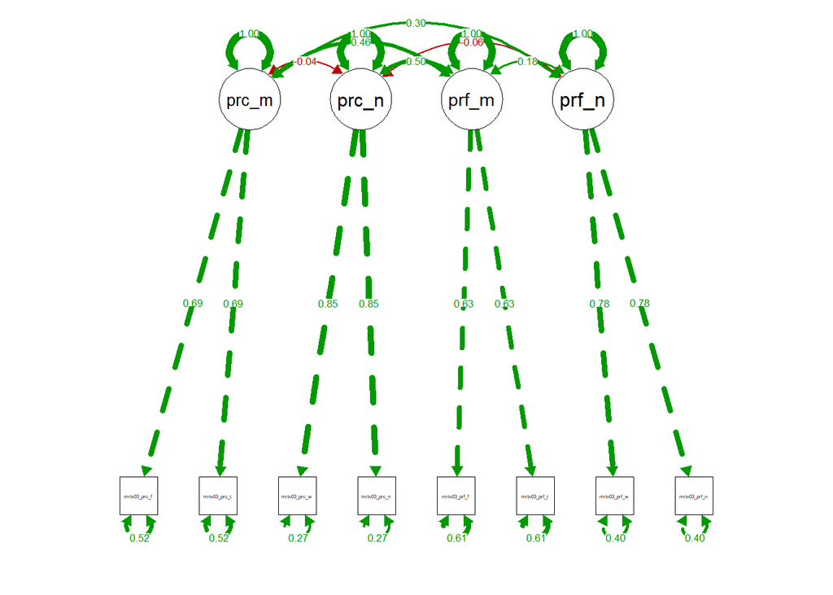

```
## chisq.scaled           df          cfi   cfi.scaled   cfi.robust
##  54.64691498  18.00000000   0.95176935   0.95103426   0.95471247
##        rmsea rmsea.scaled rmsea.robust
##   0.06072423   0.05404631   0.05860871
## chisq.scaled           df          cfi   cfi.scaled   cfi.robust
##  59.09776813  18.00000000   0.99254921   0.98250283           NA
##        rmsea rmsea.scaled rmsea.robust
##   0.04275195   0.05727542           NA
```

```r
#summary(fit3_o,standardized=TRUE, fit.measures=TRUE)
fitmeasures(fit3_o.tau)[c("chisq.scaled","df","cfi","cfi.scaled","cfi.robust","rmsea","rmsea.scaled","rmsea.robust")]
semPlot::semPaths(object = fit3_o.tau,what = "std",thresholds = FALSE, intercepts = FALSE,fade=FALSE, curve = 1.5)
```

```r
rbind(fitmeasures(fit3_o)[c("chisq.scaled","df","cfi","cfi.scaled","cfi.robust","rmsea","rmsea.scaled","rmsea.robust")],
      fitmeasures(fit3_o.tau)[c("chisq.scaled","df","cfi","cfi.scaled","cfi.robust","rmsea","rmsea.scaled","rmsea.robust")])
```

```
##      chisq.scaled df       cfi cfi.scaled cfi.robust      rmsea rmsea.scaled
## [1,]     60.02457 14 0.9918360  0.9804053         NA 0.05074320   0.06872682
## [2,]     59.09777 18 0.9925492  0.9825028         NA 0.04275195   0.05727542
##      rmsea.robust
## [1,]           NA
## [2,]           NA
```

```r
anova(fit3_o,fit3_o.tau)
```

```
## Scaled Chi-Squared Difference Test (method = "satorra.2000")
##
## lavaan NOTE:
##     The "Chisq" column contains standard test statistics, not the
##     robust test that should be reported per model. A robust difference
##     test is a function of two standard (not robust) statistics.
##
##            Df AIC BIC  Chisq Chisq diff Df diff Pr(>Chisq)
## fit3_o     14         39.090
## fit3_o.tau 18         40.898     2.3387       4     0.6737
```

> **NOTA:** El modelo con igualdad de cargas factoriales no deteriora significativamente el ajuste del modelo.

## 2.4 Version 04: muestra completa (N=2236)

| Statistic | N | Mean | St. Dev. | Min | Pctl(25) | Pctl(75) | Max |
| --- | --- | --- | --- | --- | --- | --- | --- |
| perc_effort | 2,142 | 3.200 | 1.380 | 1.000 | 2.000 | 4.000 | 5.000 |
| perc_talent | 2,141 | 3.024 | 1.161 | 1.000 | 2.000 | 4.000 | 5.000 |
| perc_wpart | 2,141 | 3.660 | 1.361 | 1.000 | 3.000 | 5.000 | 5.000 |
| perc_netw | 2,141 | 3.787 | 1.242 | 1.000 | 3.000 | 5.000 | 5.000 |
| pref_effort | 2,141 | 3.894 | 1.254 | 1.000 | 3.000 | 5.000 | 5.000 |
| pref_talent | 2,141 | 3.243 | 1.188 | 1.000 | 2.000 | 4.000 | 5.000 |
| pref_wpart | 2,141 | 2.688 | 1.175 | 1.000 | 2.000 | 4.000 | 5.000 |
| pref_netw | 2,141 | 2.408 | 1.106 | 1.000 | 2.000 | 3.000 | 5.000 |

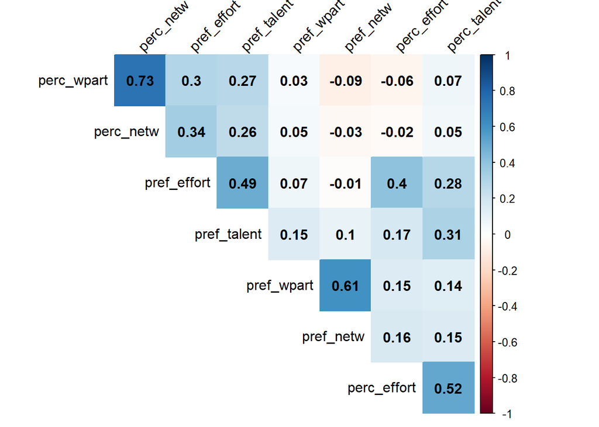

```r
cor04<-polychoric(select(dat04,perc_effort,perc_talent,perc_wpart,perc_netw,pref_effort,pref_talent,pref_wpart,pref_netw))
corrplot(cor04$rho, method="color",type = "upper", order = "hclust", tl.col = "black", tl.srt = 45,addCoef.col = "black",diag = FALSE)
```

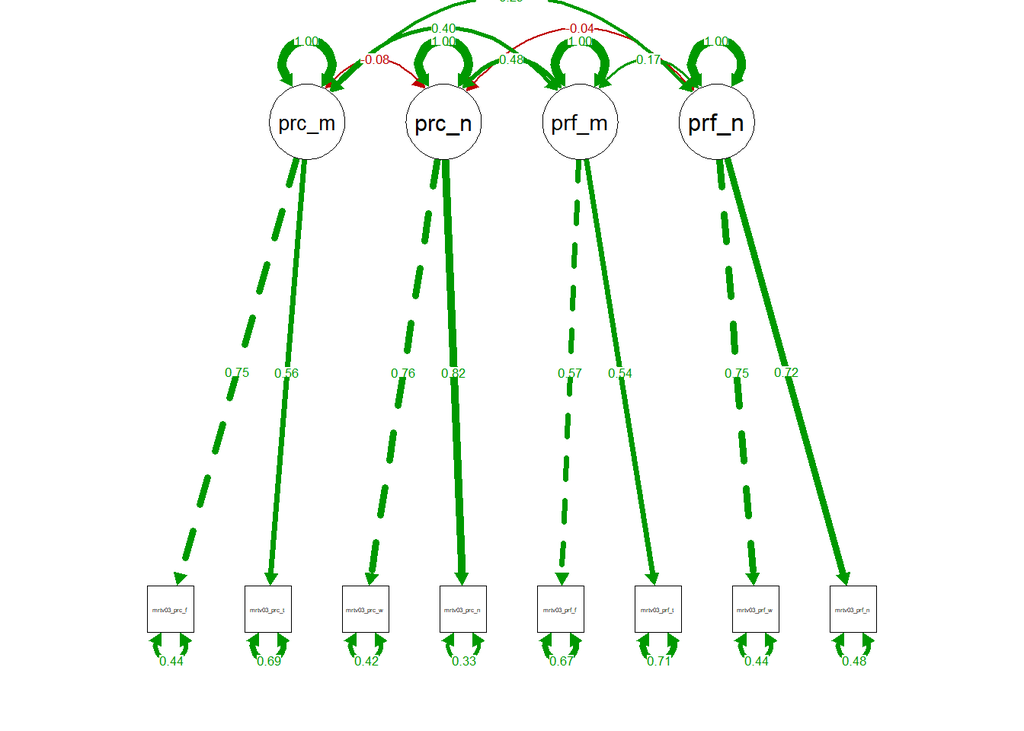

```r
model04 <- '
perc_merit =~ perc_effort+perc_talent
perc_nmerit=~perc_wpart +perc_netw
pref_merit =~ pref_effort+pref_talent
pref_nmerit=~pref_wpart +pref_netw'

fit4_c <- cfa(model = model04,data = dat04,estimator="MLR",std.lv=FALSE) # Continuo/ estimador ML Robust

fit4_o <- cfa(model = model04,data = dat04,ordered = c("perc_effort","perc_talent",
                                                       "perc_wpart","perc_netw",
                                                       "pref_effort","pref_talent",
                                                       "pref_wpart","pref_netw"),std.lv=FALSE)
#---------------------------------------------------#
#summary(fit4_c,standardized=TRUE, fit.measures=TRUE)
fitmeasures(fit4_c)[c("chisq.scaled","df","cfi","cfi.scaled","cfi.robust","rmsea","rmsea.scaled","rmsea.robust")]
semPlot::semPaths(object = fit3_c,what = "std",thresholds = FALSE, intercepts = FALSE,fade=FALSE,curve = 2)
```

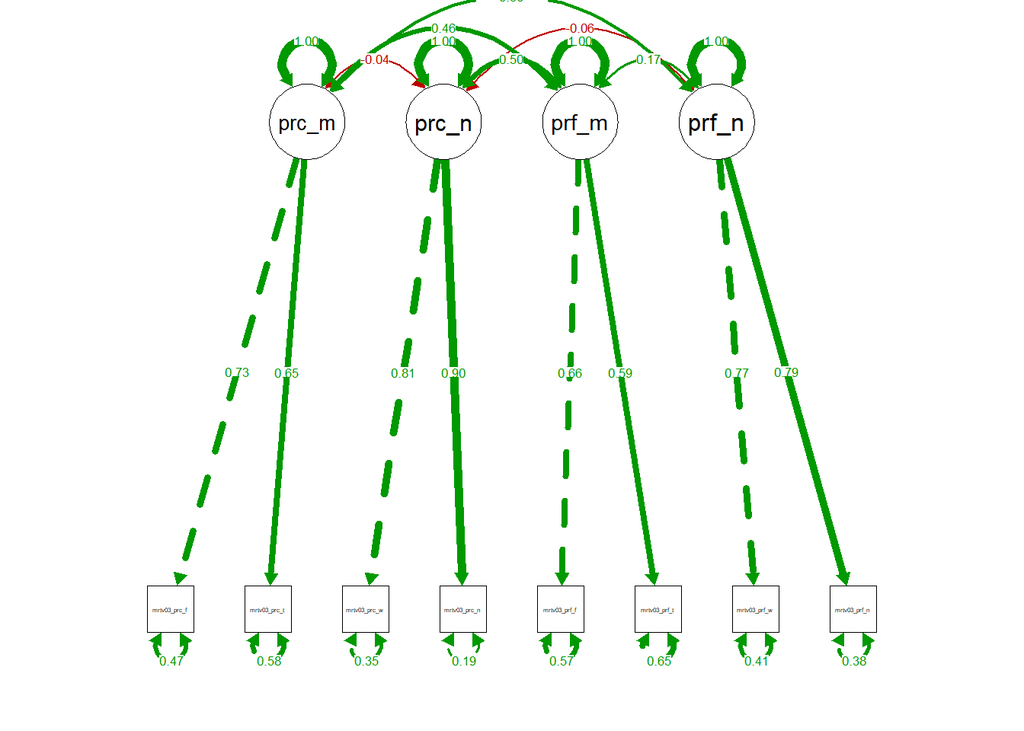

```
## chisq.scaled           df          cfi   cfi.scaled   cfi.robust
## 181.10487966  14.00000000   0.95270053   0.94250163   0.95276313
##        rmsea rmsea.scaled rmsea.robust
##   0.07634040   0.07466588   0.07621226
## chisq.scaled           df          cfi   cfi.scaled   cfi.robust
## 200.77235322  14.00000000   0.99018169   0.97680332           NA
##        rmsea rmsea.scaled rmsea.robust
##   0.05987601   0.07895605           NA
```

```r
#summary(fit4_o,standardized=TRUE, fit.measures=TRUE)
fitmeasures(fit4_o)[c("chisq.scaled","df","cfi","cfi.scaled","cfi.robust","rmsea","rmsea.scaled","rmsea.robust")]
semPlot::semPaths(object = fit3_o,what = "std",thresholds = FALSE, intercepts = FALSE,fade=FALSE,curve = 2)
```

### 2.4.1 Resumen ajuste ola 01

```r
sum_fit<- bind_rows(fitmeasures(fit1_c)[c("chisq.scaled","df","cfi","cfi.scaled","cfi.robust","rmsea","rmsea.scaled","rmsea.robust")],
                    fitmeasures(fit1_o)[c("chisq.scaled","df","cfi","cfi.scaled","cfi.robust","rmsea","rmsea.scaled","rmsea.robust")],
                    fitmeasures(fit2_c)[c("chisq.scaled","df","cfi","cfi.scaled","cfi.robust","rmsea","rmsea.scaled","rmsea.robust")],
                    fitmeasures(fit2_o)[c("chisq.scaled","df","cfi","cfi.scaled","cfi.robust","rmsea","rmsea.scaled","rmsea.robust")],
                    fitmeasures(fit3_c)[c("chisq.scaled","df","cfi","cfi.scaled","cfi.robust","rmsea","rmsea.scaled","rmsea.robust")],
                    fitmeasures(fit3_o)[c("chisq.scaled","df","cfi","cfi.scaled","cfi.robust","rmsea","rmsea.scaled","rmsea.robust")],
                    fitmeasures(fit4_c)[c("chisq.scaled","df","cfi","cfi.scaled","cfi.robust","rmsea","rmsea.scaled","rmsea.robust")],
                    fitmeasures(fit4_o)[c("chisq.scaled","df","cfi","cfi.scaled","cfi.robust","rmsea","rmsea.scaled","rmsea.robust")])
sum_fit$mod <- c("Modelo 1","Modelo 1","Modelo 2","Modelo 2","Modelo 3","Modelo 3","Modelo 4","Modelo 4")
sum_fit$est <- c("Continuo","Ordinal","Continuo","Ordinal","Continuo","Ordinal","Continuo","Ordinal")
sum_fit <- select(sum_fit,mod,est,everything())

kable(sum_fit,digits = 3,format = "html",row.names = F,booktabs=T, caption = "Resumen estadísticos de ajuste ola 1") %>% kable_styling(full_width = F) %>%
  collapse_rows(columns = 1,valign = "middle")  %>%
  footnote(number = c("Modelo 1: fixed order by percepction/preference",
                      "Modelo 2: fixed order by topic (i.e: effort)",
                      "Modelo 3: Randomized order",
                      "Modelo 4: Complete sample"))
```

Resumen estadísticos de ajuste ola 1

| mod | est | chisq.scaled | df | cfi | cfi.scaled | cfi.robust | rmsea | rmsea.scaled | rmsea.robust |
| --- | --- | --- | --- | --- | --- | --- | --- | --- | --- |
| Modelo 1 | Continuo | 42.935 | 14 | 0.979 | 0.977 | 0.980 | 0.058 | 0.054 | 0.057 |
|  | Ordinal | 46.114 | 14 | 0.998 | 0.992 |  | 0.038 | 0.057 |  |
| Modelo 2 | Continuo | 100.062 | 14 | 0.926 | 0.912 | 0.926 | 0.096 | 0.093 | 0.095 |
|  | Ordinal | 101.482 | 14 | 0.984 | 0.962 |  | 0.071 | 0.094 |  |
| Modelo 3 | Continuo | 57.058 | 14 | 0.952 | 0.942 | 0.952 | 0.069 | 0.066 | 0.068 |
|  | Ordinal | 60.025 | 14 | 0.992 | 0.980 |  | 0.051 | 0.069 |  |
| Modelo 4 | Continuo | 181.105 | 14 | 0.953 | 0.943 | 0.953 | 0.076 | 0.075 | 0.076 |
|  | Ordinal | 200.772 | 14 | 0.990 | 0.977 |  | 0.060 | 0.079 |  |

<sup>1</sup> Modelo 1: fixed order by percepction/preference  
<sup>2</sup> Modelo 2: fixed order by topic (i.e: effort)  
<sup>3</sup> Modelo 3: Randomized order  
<sup>4</sup> Modelo 4: Complete sample

## 2.5 Análisis por Grupos múltiples

```r
model04 <- '
perc_merit =~ perc_effort+perc_talent
perc_nmerit=~perc_wpart +perc_netw
pref_merit =~ pref_effort+pref_talent
pref_nmerit=~pref_wpart +pref_netw'

fit4_c_mg <- cfa(model = model04,data = dat04,estimator="MLR",std.lv=FALSE,group = "grupo") # Continuo/ estimador ML Robust

fit4_o_mg <- cfa(model = model04,data = dat04,ordered = c("perc_effort","perc_talent",
                                                       "perc_wpart","perc_netw",
                                                       "pref_effort","pref_talent",
                                                       "pref_wpart","pref_netw"),std.lv=FALSE, group = "grupo")
#---------------------------------------------------#
#summary(fit4_c_mg,standardized=TRUE, fit.measures=TRUE)
fitmeasures(fit4_c_mg)[c("cfi","cfi.scaled","cfi.robust","rmsea","rmsea.scaled","rmsea.robust")]
```

```
##          cfi   cfi.scaled   cfi.robust        rmsea rmsea.scaled
##   0.95494030   0.94697921   0.95532301   0.07575741   0.07314653
## rmsea.robust
##   0.07522301
```

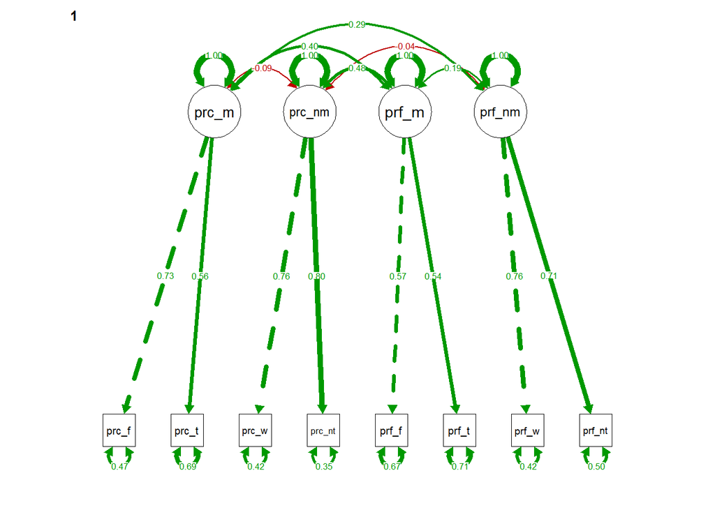

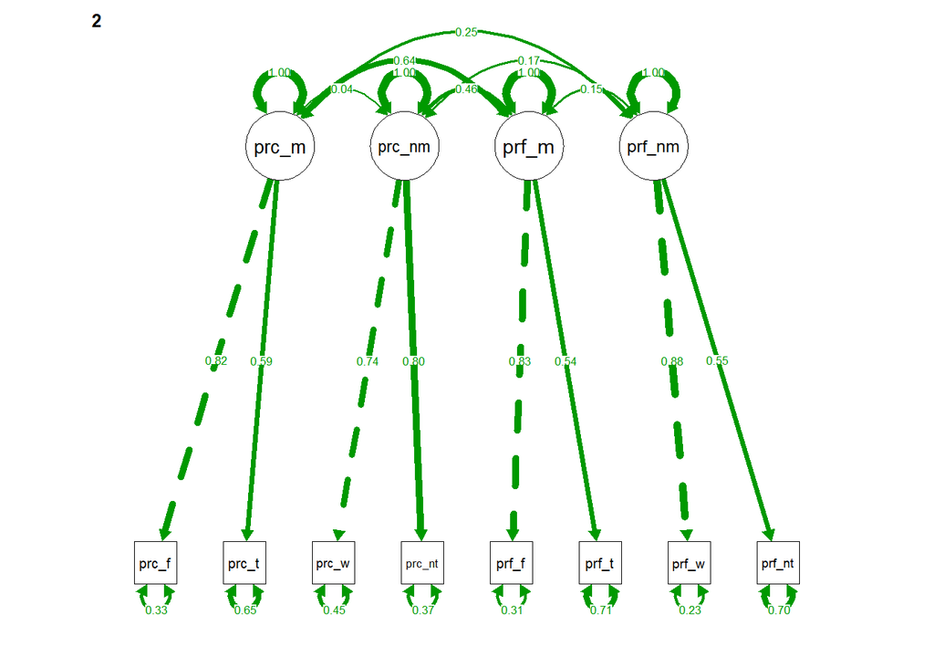

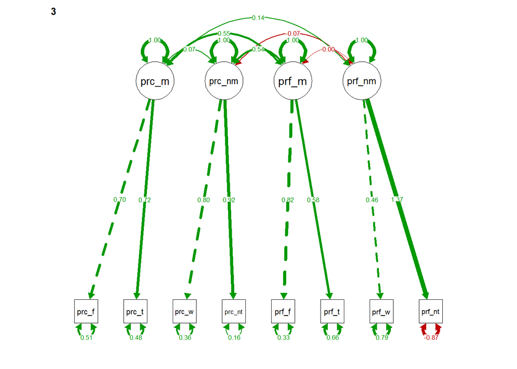

```r
semPlot::semPaths(object = fit4_c_mg,what = "std",thresholds = FALSE, intercepts = FALSE, fade=FALSE, curve=2)
```

```r
#summary(fit4_o_mg,standardized=TRUE, fit.measures=TRUE)
fitmeasures(fit4_o_mg)[c("cfi","cfi.scaled","cfi.robust","rmsea","rmsea.scaled","rmsea.robust")]
```

```
##          cfi   cfi.scaled   cfi.robust        rmsea rmsea.scaled
##   0.99236975   0.98072106           NA   0.05571542   0.07542086
## rmsea.robust
##           NA
```

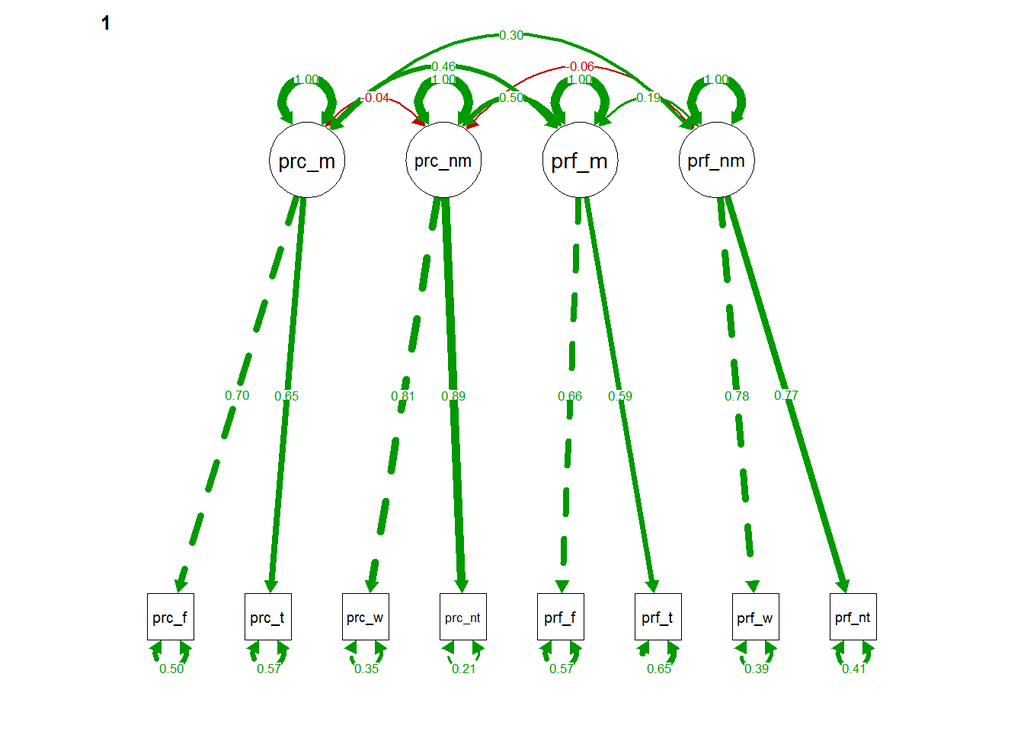

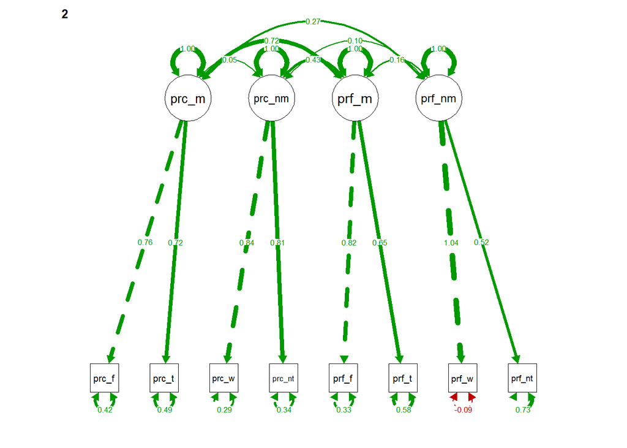

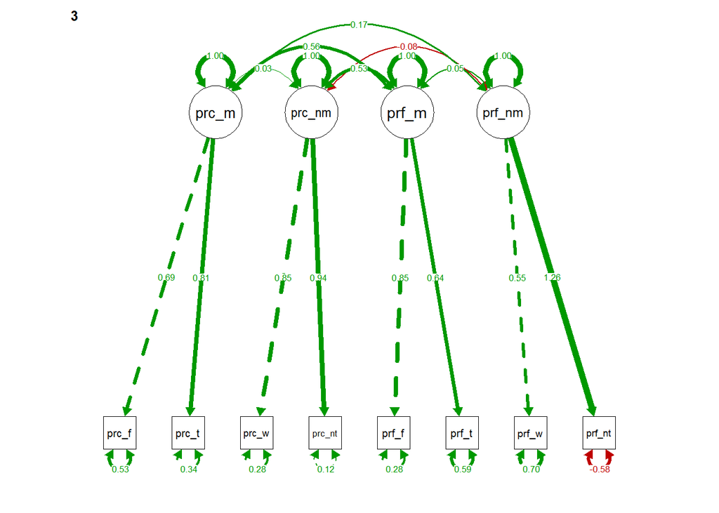

```r
semPlot::semPaths(object = fit4_o_mg,what = "std",thresholds = FALSE, intercepts = FALSE,fade=FALSE, curve=2)
```

Cosas por probar:

- V01+V02: cargas y fit
- V01+V03: cargas y fit
- V02+V03: cargas y fit

# 3 Modelo Factorial de Segundo Orden:

## 3.1 a. Factor de segundo orden por Percepción y Preferencia

```r
model04b1or <- '
perc_merit=~ perc_effort+perc_talent
perc_nmerit=~perc_wpart +perc_netw
pref_merit=~ pref_effort+pref_talent
pref_nmerit=~pref_wpart +pref_netw
percep=~ perc_merit + perc_nmerit
prefer=~ pref_merit + pref_nmerit'

fit4a_c <- cfa(model = model04b1or,data = dat04, estimator="MLR")

fit4b_c <- cfa(model = model04b1or,data = dat04,ordered = c("perc_effort","perc_talent","perc_wpart","perc_netw",
                                                            "pref_effort","pref_talent","pref_wpart","pref_netw"))

#---------------------------------------------------#
#summary(fit4a_c,standardized=TRUE, fit.measures=TRUE)
fitmeasures(fit4a_c)[c("cfi","cfi.scaled","cfi.robust","rmsea","rmsea.scaled","rmsea.robust")]
```

```
##          cfi   cfi.scaled   cfi.robust        rmsea rmsea.scaled
##   0.94736842   0.93880041   0.94760970   0.07779789   0.07441956
## rmsea.robust
##   0.07754042
```

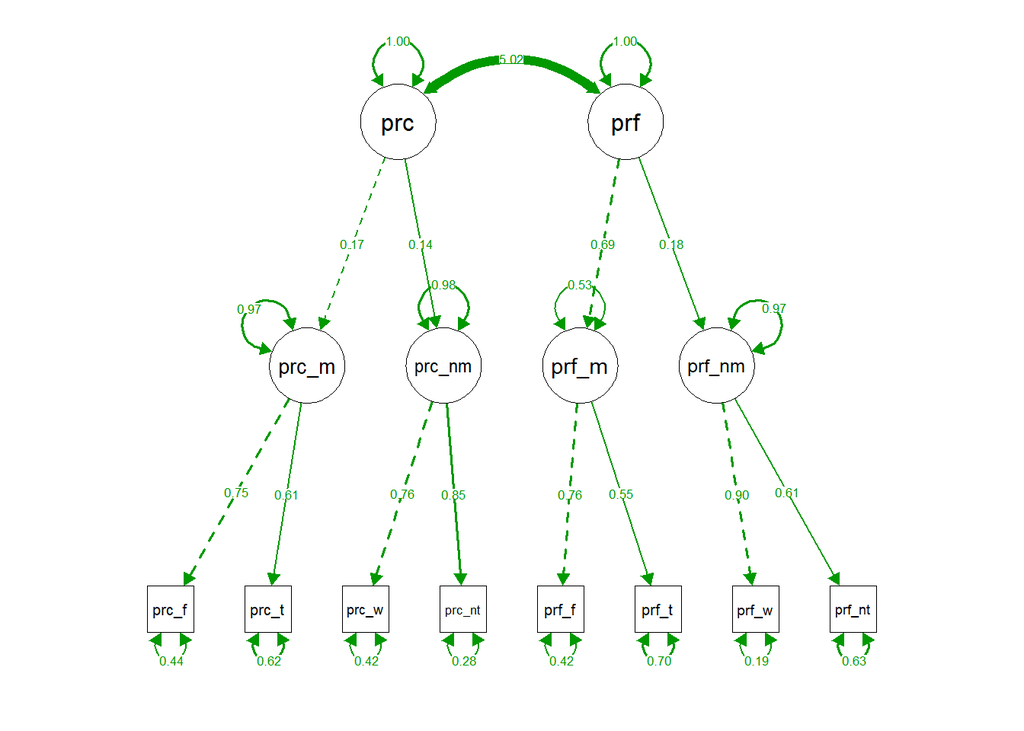

```r
semPlot::semPaths(object = fit4a_c,what = "std",thresholds = FALSE, intercepts = FALSE, fade=FALSE,curve=2)
```

```r
#summary(fit4b_c,standardized=TRUE, fit.measures=TRUE)
fitmeasures(fit4b_c)[c("cfi","cfi.scaled","cfi.robust","rmsea","rmsea.scaled","rmsea.robust")]
```

```
##          cfi   cfi.scaled   cfi.robust        rmsea rmsea.scaled
##   0.98259229   0.97082290           NA   0.07702357   0.08554841
## rmsea.robust
##           NA
```

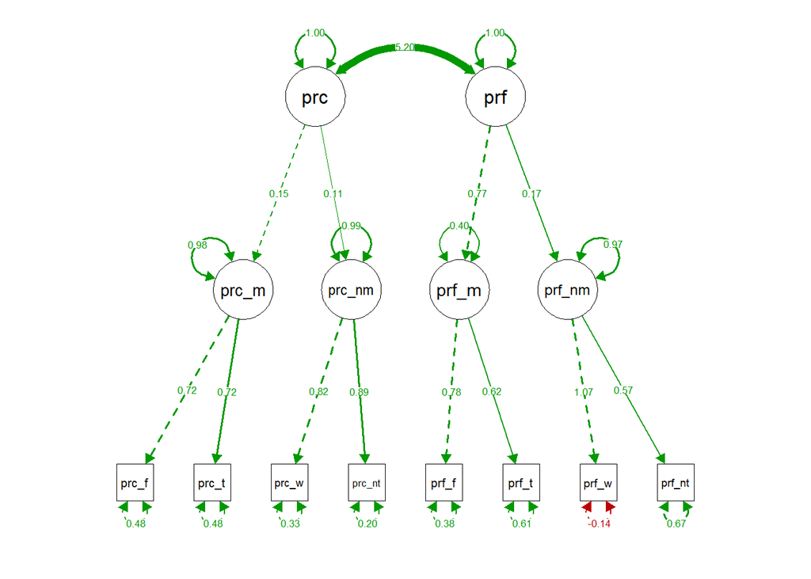

```r
semPlot::semPaths(object = fit4b_c,what = "std",thresholds = FALSE, intercepts = FALSE, fade=FALSE,curve=2)
```

> **NOTA:** Cargas factoriales de segundo orden son bajas. El ajuste del modelo no es bueno.

## 3.2 b. Factor de segundo orden por Meritocracia y No Meritocracia

```r
model04b2or <-'perc_merit=~ perc_effort+perc_talent
               perc_nmerit=~perc_wpart +perc_netw
               pref_merit=~ pref_effort+pref_talent
               pref_nmerit=~pref_wpart +pref_netw
               merit =~ perc_merit  + pref_merit
               nmerit=~ perc_nmerit + pref_nmerit'

# fit4b_c <- cfa(model = model04b2or,data = dat04,estimator="MLR") # No converge

fit4b_o <- cfa(model = model04b2or,data = dat04,
               ordered = c("perc_effort","perc_talent","perc_wpart","perc_netw",
                           "pref_effort","pref_talent","pref_wpart","pref_netw"))

#---------------------------------------------------#
# #summary(fit4b_c,standardized=TRUE, fit.measures=TRUE)
# fitmeasures(fit4b_c)[c("cfi","cfi.scaled","cfi.robust","rmsea","rmsea.scaled","rmsea.robust")]
# semPlot::semPaths(object = fit4b_c,what = "std",thresholds = FALSE, intercepts = FALSE, fade=FALSE, curve=2)

#summary(fit4b_o,standardized=TRUE, fit.measures=TRUE)
fitmeasures(fit4b_o)[c("cfi","cfi.scaled","cfi.robust","rmsea","rmsea.scaled","rmsea.robust")]
```

```
##          cfi   cfi.scaled   cfi.robust        rmsea rmsea.scaled
##   0.97583700   0.95699375           NA   0.09074615   0.10386199
## rmsea.robust
##           NA
```

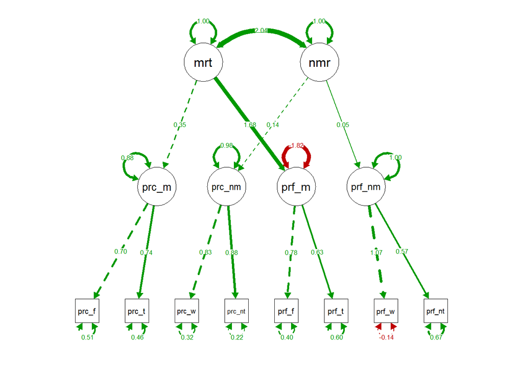

```r
semPlot::semPaths(object = fit4b_o,what = "std",thresholds = FALSE, intercepts = FALSE, fade=FALSE, curve=2)
```

> **NOTA:** El modelo estimado con MLR con factores de segundo orden “meritocracia/ no meritocracia” no converge. EL modelo estimado a través de DWLS converge, posee cargas muy bajas y una muy alta (merit~pref_merit). Fit es malo (RMSEA >.10)

# 4 Wave 02

```r
data02 <- sjlabelled::read_spss(path = "input/data/original/Estudio_3_ola2.sav",verbose = FALSE)
load(file = "input/data/proc/datawide.RData")
dat01 <- data02 %>% select(starts_with("meritv03_p"))
```

## 4.1 ATE indicadores meritocracia

```r
m01<- lm(perc_effort_w2~treat,data = wide01)
m02<- lm(perc_talent_w2~treat,data = wide01)
m03<- lm(perc_wpart_w2~treat, data = wide01)
m04<- lm(perc_netw_w2~treat,  data = wide01)
#--------------------------------------------#
m05<- lm(pref_effort_w2~treat,data = wide01)
m06<- lm(pref_talent_w2~treat,data = wide01)
m07<- lm(pref_wpart_w2 ~treat, data = wide01)
m08<- lm(pref_netw_w2  ~treat,  data = wide01)
#--------------------------------------------#
stargazer::stargazer(m01,m02,m03,m04,type = "html")
```

|  | *Dependent variable:* |  |  |  |
| --- | --- | --- | --- | --- |
|  | perc_effort_w2 | perc_talent_w2 | perc_wpart_w2 | perc_netw_w2 |
|  | (1) | (2) | (3) | (4) |
| treatpobreza | 0.061 | -0.018 | -0.047 | -0.010 |
|  | (0.072) | (0.064) | (0.077) | (0.073) |
| treatdesiguald | -0.078 | -0.092 | 0.057 | 0.020 |
|  | (0.072) | (0.063) | (0.077) | (0.072) |
| Constant | 3.322*** | 3.164*** | 3.542*** | 3.547*** |
|  | (0.051) | (0.045) | (0.054) | (0.051) |
| Observations | 1,777 | 1,777 | 1,777 | 1,777 |
| R<sup>2</sup> | 0.002 | 0.001 | 0.001 | 0.0001 |
| Adjusted R<sup>2</sup> | 0.001 | 0.0002 | -0.0001 | -0.001 |
| Residual Std. Error (df = 1774) | 1.239 | 1.094 | 1.326 | 1.249 |
| F Statistic (df = 2; 1774) | 1.844 | 1.175 | 0.907 | 0.084 |
| *Note:* | p<0.1; p<0.05; p<0.01 |  |  |  |

```r
stargazer::stargazer(m05,m06,m07,m08,type = "html")
```

|  | *Dependent variable:* |  |  |  |
| --- | --- | --- | --- | --- |
|  | pref_effort_w2 | pref_talent_w2 | pref_wpart_w2 | pref_netw_w2 |
|  | (1) | (2) | (3) | (4) |
| treatpobreza | 0.085 | 0.064 | 0.059 | -0.094 |
|  | (0.067) | (0.066) | (0.067) | (0.062) |
| treatdesiguald | 0.058 | 0.043 | -0.017 | -0.101 |
|  | (0.067) | (0.065) | (0.067) | (0.062) |
| Constant | 3.879*** | 3.237*** | 2.592*** | 2.374*** |
|  | (0.047) | (0.046) | (0.047) | (0.044) |
| Observations | 1,777 | 1,777 | 1,777 | 1,777 |
| R<sup>2</sup> | 0.001 | 0.001 | 0.001 | 0.002 |
| Adjusted R<sup>2</sup> | -0.0002 | -0.001 | -0.0003 | 0.001 |
| Residual Std. Error (df = 1774) | 1.155 | 1.128 | 1.154 | 1.065 |
| F Statistic (df = 2; 1774) | 0.841 | 0.503 | 0.709 | 1.660 |
| *Note:* | p<0.1; p<0.05; p<0.01 |  |  |  |

> **NOTA**: Los tratamientos de información no se asocian de manera estadísticamente significativa con ninguno de los indicadores de la escala de meritocracia.

## 4.2 CFA Muestra completa (Control, Desigualdad y Pobreza)

| Statistic | N | Mean | St. Dev. | Min | Pctl(25) | Pctl(75) | Max |
| --- | --- | --- | --- | --- | --- | --- | --- |
| meritv03_perc_effort | 1,772 | 3.318 | 1.240 | 1.000 | 2.000 | 4.000 | 5.000 |
| meritv03_perc_talent | 1,772 | 3.125 | 1.095 | 1.000 | 2.000 | 4.000 | 5.000 |
| meritv03_perc_wpart | 1,772 | 3.547 | 1.325 | 1.000 | 3.000 | 5.000 | 5.000 |
| meritv03_perc_netw | 1,772 | 3.549 | 1.249 | 1.000 | 3.000 | 4.000 | 5.000 |
| meritv03_pref_effort | 1,772 | 3.924 | 1.157 | 1.000 | 3.000 | 5.000 | 5.000 |
| meritv03_pref_talent | 1,772 | 3.274 | 1.128 | 1.000 | 3.000 | 4.000 | 5.000 |
| meritv03_pref_wpart | 1,772 | 2.607 | 1.154 | 1.000 | 2.000 | 3.000 | 5.000 |
| meritv03_pref_netw | 1,772 | 2.308 | 1.065 | 1.000 | 1.000 | 3.000 | 5.000 |

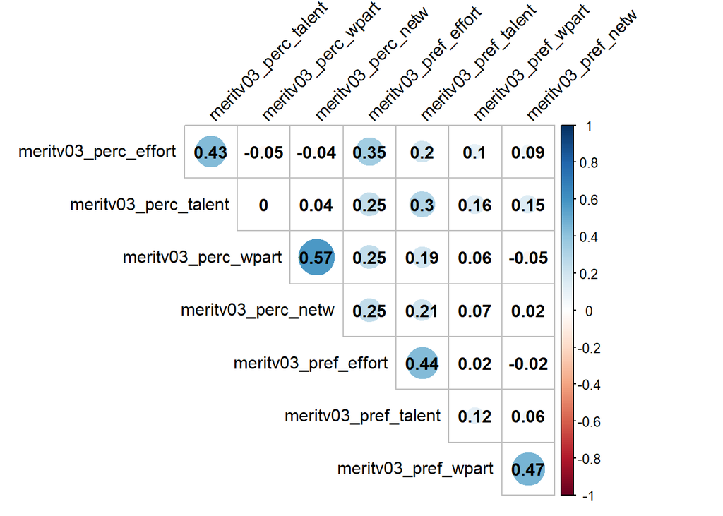

```r
dat01cor<- select(dat01,meritv03_perc_effort,meritv03_perc_talent,
                        meritv03_perc_wpart,meritv03_perc_netw,
                        meritv03_pref_effort,meritv03_pref_talent,
                        meritv03_pref_wpart,meritv03_pref_netw)
cor01<-polychoric(dat01cor)
corrplot(cor01$rho, type = "upper", tl.col = "black", tl.srt = 45,addCoef.col = "black",diag = FALSE)
```

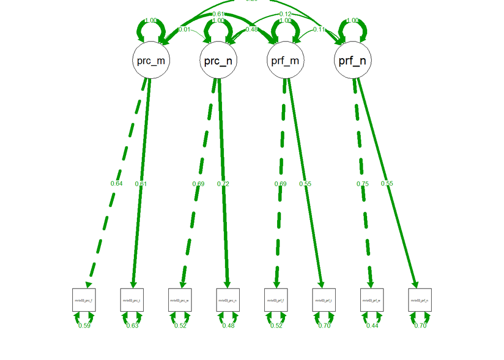

```r
model03 <- '
perc_merit=~meritv03_perc_effort+meritv03_perc_talent
perc_nmerit=~meritv03_perc_wpart+meritv03_perc_netw
pref_merit=~meritv03_pref_effort+meritv03_pref_talent
pref_nmerit=~meritv03_pref_wpart+meritv03_pref_netw'

fitw02_c <- cfa(model = model03,data = dat01,estimator="MLR",std.lv=FALSE) # Continuo/ estimador ML Robust

fitw02_o <- cfa(model = model03,data = dat01,ordered = c("meritv03_perc_effort","meritv03_perc_talent",
                                                          "meritv03_perc_wpart","meritv03_perc_netw",
                                                          "meritv03_pref_effort","meritv03_pref_talent",
                                                          "meritv03_pref_wpart","meritv03_pref_netw"))
#---------------------------------------------------#
#summary(fitw02_c,standardized=TRUE, fit.measures=TRUE)
fitmeasures(fitw02_c)[c("cfi","cfi.scaled","cfi.robust","rmsea","rmsea.scaled","rmsea.robust")]
semPlot::semPaths(object = fitw02_c,what = "std",thresholds = FALSE, intercepts = FALSE,fade=FALSE,curve=2)
```

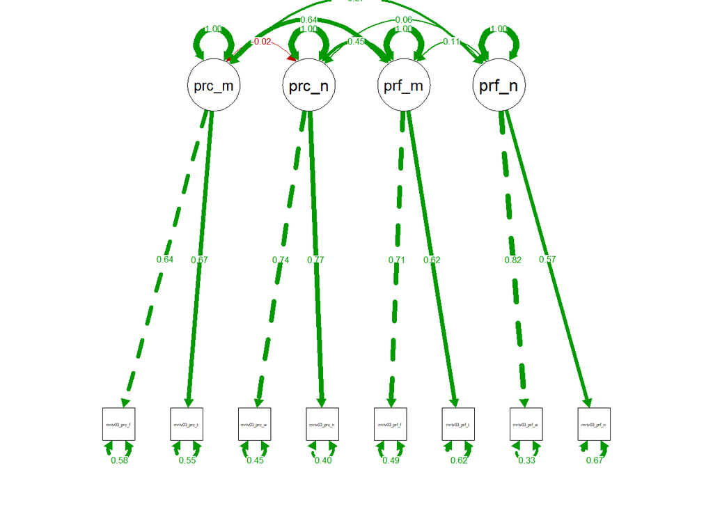

```
##          cfi   cfi.scaled   cfi.robust        rmsea rmsea.scaled
##   0.96683191   0.96480728   0.96795005   0.05064198   0.04589567
## rmsea.robust
##   0.04967688
##          cfi   cfi.scaled   cfi.robust        rmsea rmsea.scaled
##   0.98784345   0.97481090           NA   0.04672993   0.05956625
## rmsea.robust
##           NA
```

```r
#summary(fitw02_o,standardized=TRUE, fit.measures=TRUE)
fitmeasures(fitw02_o)[c("cfi","cfi.scaled","cfi.robust","rmsea","rmsea.scaled","rmsea.robust")]
semPlot::semPaths(object = fitw02_o,what = "std",thresholds = FALSE, intercepts = FALSE,fade=FALSE,curve=2)
```

### 4.2.1 Factor de segundo orden

```r
modw2 <- '
perc_merit=~meritv03_perc_effort+meritv03_perc_talent
perc_nmerit=~meritv03_perc_wpart+meritv03_perc_netw
pref_merit=~meritv03_pref_effort+meritv03_pref_talent
pref_nmerit=~meritv03_pref_wpart+meritv03_pref_netw
merit =~perc_merit+pref_merit
nmerit=~perc_nmerit+pref_nmerit'

# mod2_merit_c <- cfa(model = modw2,data = dat01) # Continuo/ estimador ML Robust

mod2_merit_o <- cfa(model = modw2,data = dat01,ordered = c("meritv03_perc_effort","meritv03_perc_talent",
                                                           "meritv03_perc_wpart","meritv03_perc_netw",
                                                           "meritv03_pref_effort","meritv03_pref_talent",
                                                           "meritv03_pref_wpart","meritv03_pref_netw"))

#---------------------------------------------------#
# #summary(mod2_merit_c,standardized=TRUE, fit.measures=TRUE)
# fitmeasures(mod2_merit_c)[c("cfi","cfi.scaled","cfi.robust","rmsea","rmsea.scaled","rmsea.robust")]
# semPlot::semPaths(object = mod2_merit_c,what = "std",thresholds = FALSE, intercepts = FALSE)

#summary(mod2_merit_o,standardized=TRUE, fit.measures=TRUE)
fitmeasures(mod2_merit_o)[c("cfi","cfi.scaled","cfi.robust","rmsea","rmsea.scaled","rmsea.robust")]
```

```
##          cfi   cfi.scaled   cfi.robust        rmsea rmsea.scaled
##   0.96479952   0.94371851           NA   0.07682146   0.08601914
## rmsea.robust
##           NA
```

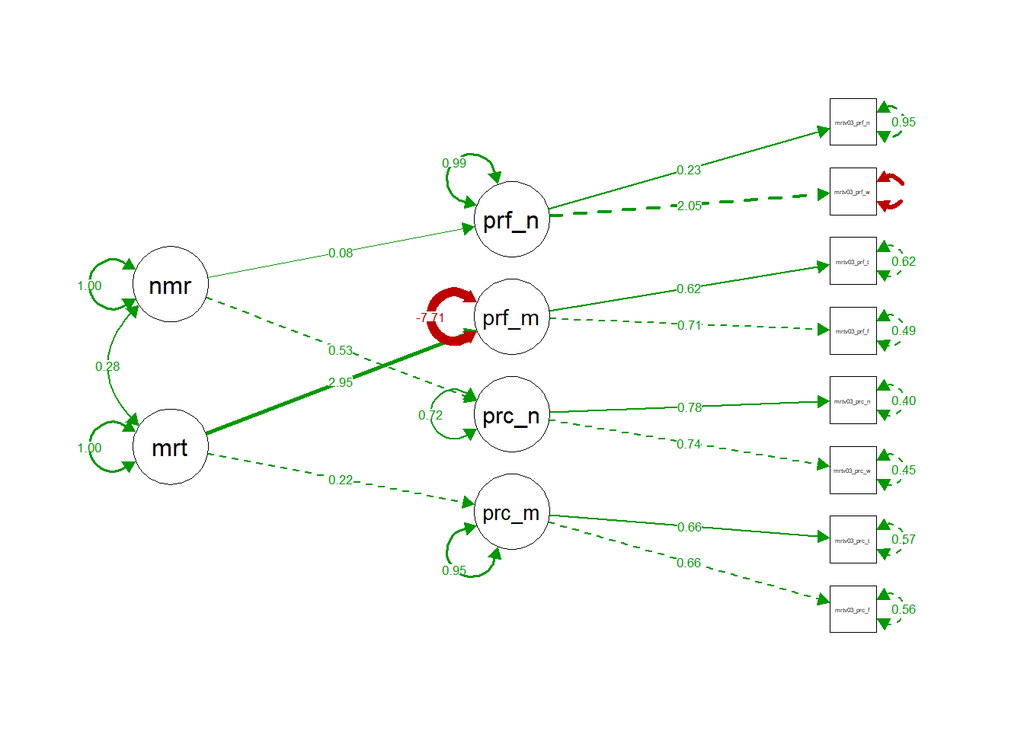

```r
semPlot::semPaths(object = mod2_merit_o,what = "std",thresholds = FALSE, intercepts = FALSE,fade=FALSE, curve=2, rotation=2)
```

> - Factor de segundo orden usando MLR no converge.
> - Factor de segundo orden usando DWLS converge, pero las cargas no son buenas y el ajuste tampoco.

## 4.3 CFA Muestra Control

```r
w02con <- data02 %>% filter(FL_6_DO_Control==1) %>% select(starts_with("meritv03_p"))
```

| Statistic | N | Mean | St. Dev. | Min | Pctl(25) | Pctl(75) | Max |
| --- | --- | --- | --- | --- | --- | --- | --- |
| meritv03_perc_effort | 595 | 3.324 | 1.239 | 1.000 | 2.000 | 4.000 | 5.000 |
| meritv03_perc_talent | 595 | 3.165 | 1.087 | 1.000 | 2.000 | 4.000 | 5.000 |
| meritv03_perc_wpart | 595 | 3.536 | 1.296 | 1.000 | 3.000 | 5.000 | 5.000 |
| meritv03_perc_netw | 595 | 3.541 | 1.220 | 1.000 | 3.000 | 4.000 | 5.000 |
| meritv03_pref_effort | 595 | 3.877 | 1.166 | 1.000 | 3.000 | 5.000 | 5.000 |
| meritv03_pref_talent | 595 | 3.239 | 1.118 | 1.000 | 2.500 | 4.000 | 5.000 |
| meritv03_pref_wpart | 595 | 2.588 | 1.147 | 1.000 | 2.000 | 3.000 | 5.000 |
| meritv03_pref_netw | 595 | 2.370 | 1.074 | 1.000 | 2.000 | 3.000 | 5.000 |

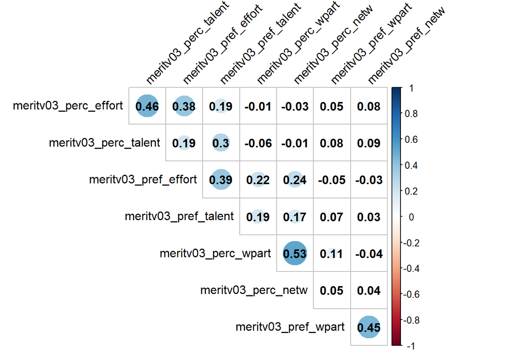

```r
corw02_1<-polychoric(w02con)
corrplot(corw02_1$rho, type = "upper", order = "hclust", tl.col = "black", tl.srt = 45,addCoef.col = "black",diag = FALSE)
```

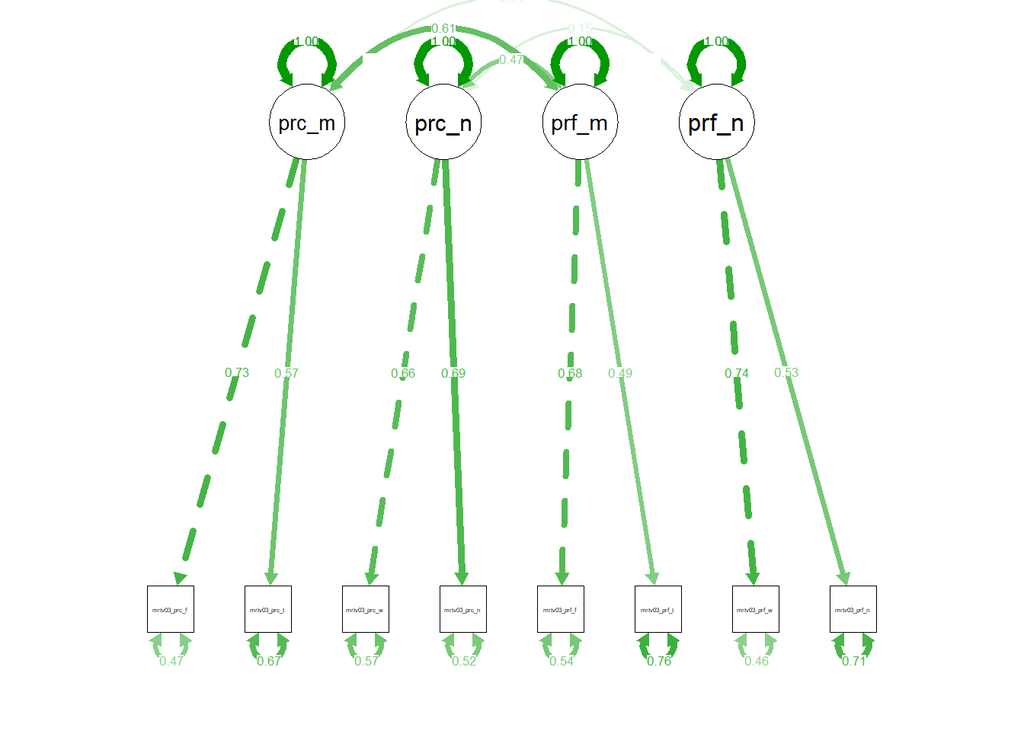

```r
model03 <- '
perc_merit=~meritv03_perc_effort+meritv03_perc_talent
perc_nmerit=~meritv03_perc_wpart+meritv03_perc_netw
pref_merit=~meritv03_pref_effort+meritv03_pref_talent
pref_nmerit=~meritv03_pref_wpart+meritv03_pref_netw'

fitw02a_c <- cfa(model = model03,data = w02con,estimator="MLR") # Continuo/ estimador ML Robust

fitw02a_o <- cfa(model = model03,data = w02con,ordered = c("meritv03_perc_effort","meritv03_perc_talent",
                                                           "meritv03_perc_wpart","meritv03_perc_netw",
                                                           "meritv03_pref_effort","meritv03_pref_talent",
                                                           "meritv03_pref_wpart","meritv03_pref_netw"))

#---------------------------------------------------#
#summary(fitw02a_c,standardized=TRUE, fit.measures=TRUE)
fitmeasures(fitw02a_c)[c("cfi","cfi.scaled","cfi.robust","rmsea","rmsea.scaled","rmsea.robust")]
semPlot::semPaths(object = fitw02a_c,what = "std",thresholds = FALSE, intercepts = FALSE, curve=2)
```

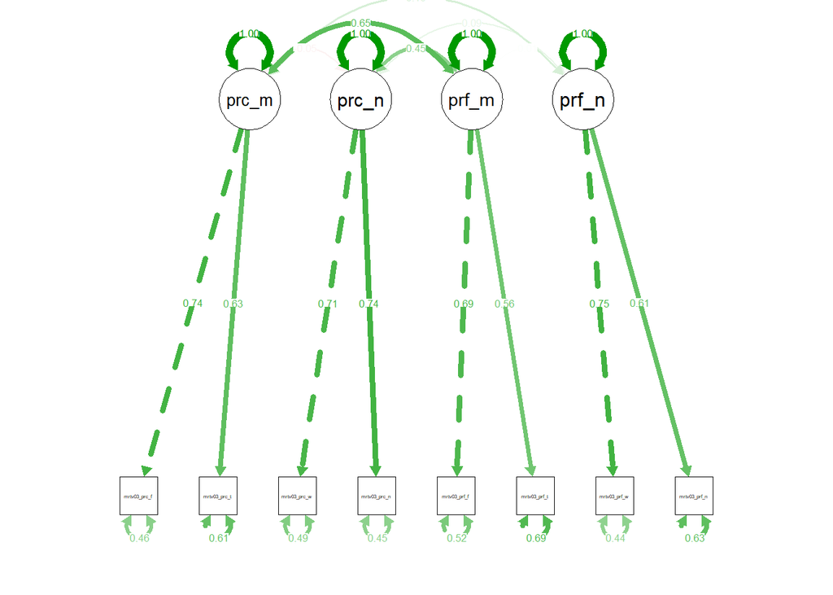

```
##          cfi   cfi.scaled   cfi.robust        rmsea rmsea.scaled
##   0.95300796   0.95202309   0.95683934   0.05713915   0.04989786
## rmsea.robust
##   0.05433717
##          cfi   cfi.scaled   cfi.robust        rmsea rmsea.scaled
##   0.98848464   0.97507075           NA   0.04333340   0.05692432
## rmsea.robust
##           NA
```

```r
#summary(fitw02a_o,standardized=TRUE, fit.measures=TRUE)
fitmeasures(fitw02a_o)[c("cfi","cfi.scaled","cfi.robust","rmsea","rmsea.scaled","rmsea.robust")]
semPlot::semPaths(object = fitw02a_o,what = "std",thresholds = FALSE, intercepts = FALSE, curve=2)
```